# Initial Analysis of NFL Play-by-Play Data

Cass Crews

# Loading Packages

```r
library(tidyverse)
```

```r
library(lubridate)
library(nflplotR)
library(plotly)
library(janitor)
library(gt)

options(scipen=999)

source("nfl_plays/helpers.R")
```

# Reading in Data

```r
#Reading in main dataset
play_data<-read_csv("nfl_plays/2018_2019_rp_plays.csv")
#Reading in secondary dataset for win probability time series and creating needed variables
play_data2<-read_csv("nfl_plays/2018_2019_all_plays.csv") |>
  mutate(days_in_season=as.numeric(difftime(game_date,ymd("2018-09-04"),units="days"))) |>
  mutate(week=floor(days_in_season/7)+1) |>
  mutate(game_label=paste0(away_team," at ",home_team))
```

# Categorical Variable NUmeric Summaries

As an initial step, let’s explore the distribution between passes and runs.

```r
#Generating pass-run breakdown
table1<-play_data |>
  #Generating contingency table
  tabyl(play_type,show_na=FALSE) |>
  adorn_pct_formatting(digits=1)

#Converting to HTML table with clean labels
gt(table1) |>
  cols_label(
    play_type="Play Type",n="Number of Plays",percent="Percent of Plays"
  )
```

| Play Type | Number of Plays | Percent of Plays |
| --- | --- | --- |
| pass | 17600 | 59.4% |
| run | 12020 | 40.6% |

Thus, 59.4% of plays in the 2018-2019 season were pass plays.

Which type of play was more likely to result in a turnover?

```r
#Generating turnover rates by play type
table2<-play_data |>
  #Identifying turnovers as lost fumbles and interceptions
  mutate(turnover=if_else(fumble_lost==1 | interception==1,"yes","no")) |>
  #Converting to contingency table with row percentages
  tabyl(play_type,turnover,show_na=FALSE) |>
  adorn_percentages("row") |>
  adorn_pct_formatting(digits=1) |>
  adorn_ns("front")

#Converting to HTML table with clean labels
gt(table2) |>
  cols_label(play_type="Play Type") |>
  tab_spanner(label="Turnover?",columns=2:length(table2))
```

| Play Type | Turnover? no | Turnover? yes |
| --- | --- | --- |
| pass | 17,074 (97.0%) | 526 (3.0%) |
| run | 11,954 (99.5%) | 66 (0.5%) |

It seems pass plays are much more likely to result in turnovers.

How does the pass-run breakdown differ when a team is winning (or tied) and when it is losing?

```r
#Generating pass-run breakdown for winning (or tied) and losing
table3<-play_data |>
  #Creating winning indicator
  mutate(winning=if_else(score_differential>=0,"yes","no")) |>
  #Converting to contingency table with row percentages
  tabyl(winning,play_type,show_na=FALSE) |>
  adorn_percentages("row") |>
  adorn_pct_formatting(digits=1) |>
  adorn_ns("front")

#Converting to HTML table with clean labels
gt(table3) |>
  cols_label(winning="Winning or Tied?") |>
  tab_spanner(label="Play Type",columns=2:length(table2))
```

| Winning or Tied? | Play Type pass | Play Type run |
| --- | --- | --- |
| no | 9,314 (66.8%) | 4,637 (33.2%) |
| yes | 8,286 (52.9%) | 7,383 (47.1%) |

Not surprisingly, teams are more likely to pass when they are losing than when they are winning.

How does the run-pass breakdown vary across quarters?

```r
#Generating pass-run breakdown by quarter
table4<-play_data |>
  #Converting quarter to factor
  mutate(qtr=factor(qtr,levels=1:5,labels=c(1:4,"Overtime"))) |>
  #Generating contingency table with row percentages
  tabyl(qtr,play_type,show_na=FALSE) |>
  adorn_percentages("row") |>
  adorn_pct_formatting(digits=1) |>
  adorn_ns("front")

#Converting to HTML table with clean labels
gt(table4) |>
  cols_label(qtr="Quarter") |>
  tab_spanner(label="Play Type",columns=2:length(table2))
```

| Quarter | Play Type pass | Play Type run |
| --- | --- | --- |
| 1 | 3,660 (54.6%) | 3,049 (45.4%) |
| 2 | 4,997 (63.2%) | 2,912 (36.8%) |
| 3 | 3,920 (57.3%) | 2,923 (42.7%) |
| 4 | 4,863 (61.6%) | 3,032 (38.4%) |
| Overtime | 160 (60.6%) | 104 (39.4%) |

Notably, passing plays are more common in quarters that end either the half or the game. This may indicate that coaches feel a greater sense of urgency near the end of the half/game.

# Numeric Variable Numeric Summaries

```r
#Generating overall summary statistics for numeric variables of interest
play_data |>
  #Generating mean, median, sd, IQR, min, and max
  summarize(across(c(yards_gained,score_differential,wp,wpa),list(Mean= ~round(mean(.x, na.rm = TRUE),4),
                                                                     Median= ~round(median(.x, na.rm = TRUE),4),
                                                                     SD= ~round(sd(.x, na.rm = TRUE),4),
                                                                     IQR= ~round(IQR(.x, na.rm = TRUE),4),
                                                                     Min= ~round(min(.x, na.rm = TRUE),4),
                                                                     Max= ~round(max(.x, na.rm = TRUE),4)),.names="{.fn}__{.col}")) |>
  pivot_longer(everything(),names_to=c(".value","variable"),names_sep="__") |>
  #Assigning clean variable name labels
  mutate(`Numeric Variable`=names(num_vars)[match(variable,num_vars)]) |>
  select(!variable) |>
  select(`Numeric Variable`,everything())
```

```
## # A tibble: 4 × 7
##   `Numeric Variable`                 Mean  Median      SD     IQR     Min    Max
##   <chr>                             <dbl>   <dbl>   <dbl>   <dbl>   <dbl>  <dbl>
## 1 Yards Gained on Play             5.72    3       9.04    9      -22     99
## 2 Score Differential Before Play… -1.64    0      11.0    11      -44     44
## 3 Offense's Win Probability Befo…  0.499   0.512   0.288   0.456    0      1
## 4 Offense's Win Probability Adde…  0.0021 -0.0016  0.0456  0.0334  -0.871  0.940
```

The game in which a single play increased the win probability by 0.94 must have had an exciting ending! I suspect the game ended on a successful Hail Mary.

Let’s explore these summary statistics by quarter to see how things like win probability added change as a game proceeds.

```r
#Generating summary statistics for numeric variables of interest by quarter
play_data |>
  #Converting quarter to factor
  mutate(qtr=factor(qtr,levels=1:5,labels=c(1:4,"Overtime"))) |>
  #Grouping by quarter
  group_by(qtr) |>
  #Generating mean, median, sd, IQR, min, and max
  summarize(across(c(yards_gained,score_differential,wp,wpa),list(Mean= ~round(mean(.x, na.rm = TRUE),4),
                                                                     Median= ~round(median(.x, na.rm = TRUE),4),
                                                                     SD= ~round(sd(.x, na.rm = TRUE),4),
                                                                     IQR= ~round(IQR(.x, na.rm = TRUE),4),
                                                                     Min= ~round(min(.x, na.rm = TRUE),4),
                                                                     Max= ~round(max(.x, na.rm = TRUE),4)),.names="{.fn}__{.col}")) |>
  pivot_longer(Mean__yards_gained:Max__wpa,names_to=c(".value","variable"),names_sep="__") |>
  arrange(variable,qtr) |>
  #Assigning clean variable name labels
  mutate(`Numeric Variable`=names(num_vars)[match(variable,num_vars)]) |>
  select(!variable) |>
  select(qtr,`Numeric Variable`,everything()) |>
  rename(Quarter=qtr)
```

```
## # A tibble: 20 × 8
##    Quarter  `Numeric Variable`      Mean  Median      SD     IQR      Min    Max
##    <fct>    <chr>                  <dbl>   <dbl>   <dbl>   <dbl>    <dbl>  <dbl>
##  1 1        Score Differential … -1.07    0       4.59    3      -21      17
##  2 2        Score Differential … -1.06    0       9.42   13      -32      32
##  3 3        Score Differential … -1.48    0      13.2    18      -42      42
##  4 4        Score Differential … -2.87   -3      13.9    18      -44      44
##  5 Overtime Score Differential … -0.496   0       1.28    1       -4       1
##  6 1        Offense's Win Proba…  0.516   0.524   0.151   0.178    0.0315  0.951
##  7 2        Offense's Win Proba…  0.519   0.521   0.256   0.418    0.0005  1
##  8 3        Offense's Win Proba…  0.506   0.515   0.320   0.594    0       1
##  9 4        Offense's Win Proba…  0.459   0.425   0.367   0.759    0       1
## 10 Overtime Offense's Win Proba…  0.495   0.507   0.159   0.249    0.133   0.881
## 11 1        Offense's Win Proba…  0.0024 -0.0052  0.0423  0.0491  -0.223   0.270
## 12 2        Offense's Win Proba…  0.0022 -0.0022  0.0364  0.031   -0.294   0.250
## 13 3        Offense's Win Proba…  0.0006 -0.0022  0.0368  0.0305  -0.282   0.281
## 14 4        Offense's Win Proba…  0.0027 -0.0001  0.0571  0.0242  -0.871   0.940
## 15 Overtime Offense's Win Proba…  0.008  -0.0167  0.124   0.125   -0.657   0.417
## 16 1        Yards Gained on Play  5.87    4       8.98    9      -16      80
## 17 2        Yards Gained on Play  5.78    4       9.13    9      -22      99
## 18 3        Yards Gained on Play  5.74    3       9.16    9      -19      97
## 19 4        Yards Gained on Play  5.52    3       8.91    8      -18      79
## 20 Overtime Yards Gained on Play  5.41    3       8.30    9      -12      49
```

I find two phenomena particularly notable: plays in the third quarter had the smallest average impact on win probability, and average yards gain was fairly stable across quarters.

# Graphical Summaries

To begin our visual analysis, let’s plot a kernel density of yards gained.

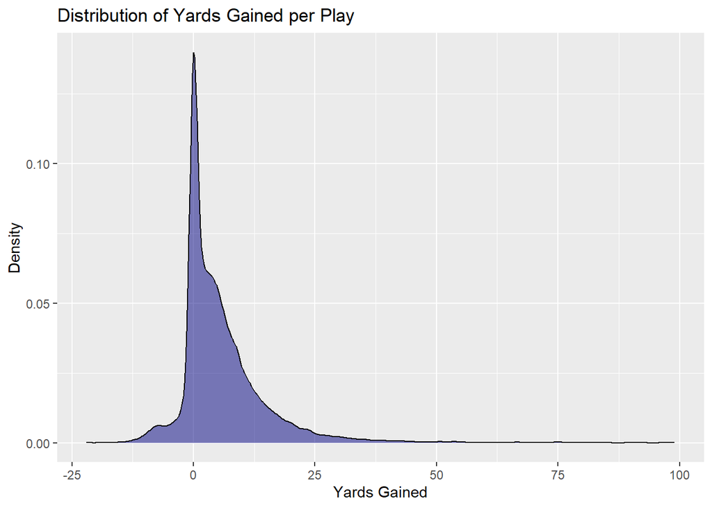

```r
#Plotting distribution of yards gained per play
ggplot(data=play_data,aes(x=yards_gained))+geom_density(alpha=0.5,fill="navy")+labs(title="Distribution of Yards Gained per Play",x="Yards Gained",y="Density")
```

Note the peak at no gain. This likely reflected the common outcome of an incompletion. Let’s plot separate kernel densities for each play type (pass and run) to see if we are correct.

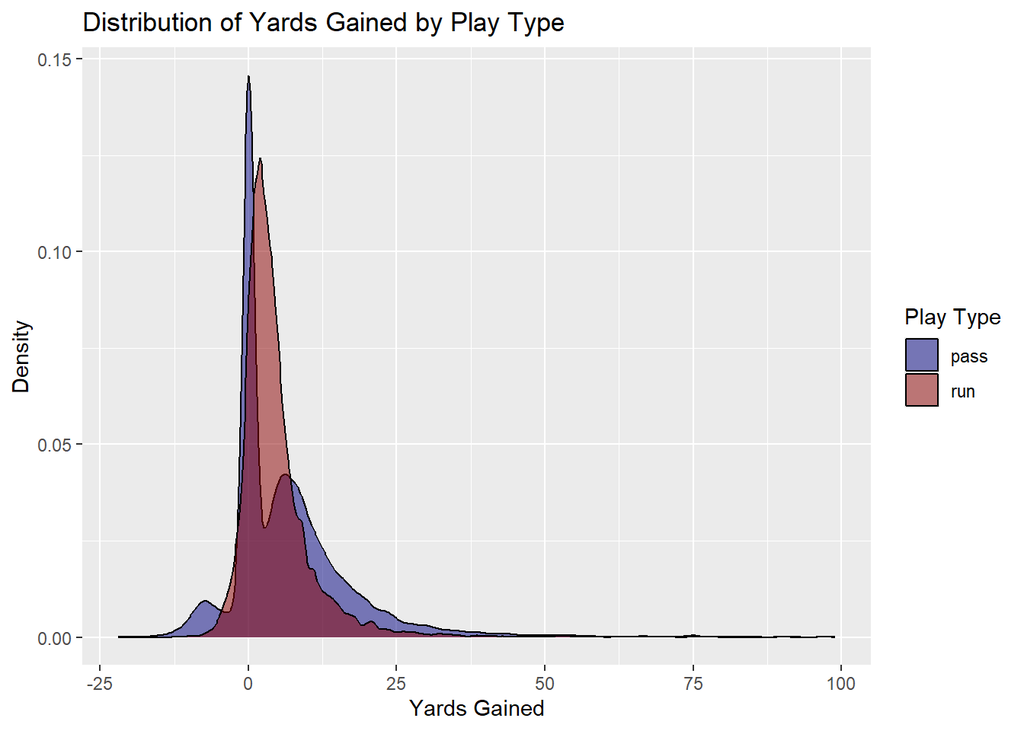

```r
#Plotting distribution of yards gained per play by play type
ggplot(data=play_data,aes(x=yards_gained,fill=play_type))+geom_density(alpha=0.5)+scale_fill_manual(values=c("navy","darkred"))+labs(title="Distribution of Yards Gained by Play Type",x="Yards Gained",y="Density",fill="Play Type")
```

When we approximate density functions for each play type, we not only see the high likelihood of an incompletion but also two additional pass-specific modes reflecting sacks and completions.

Next, we will explore the relationship between yards gained and win probability added via a scatterplot, with point colors varying by quarter.

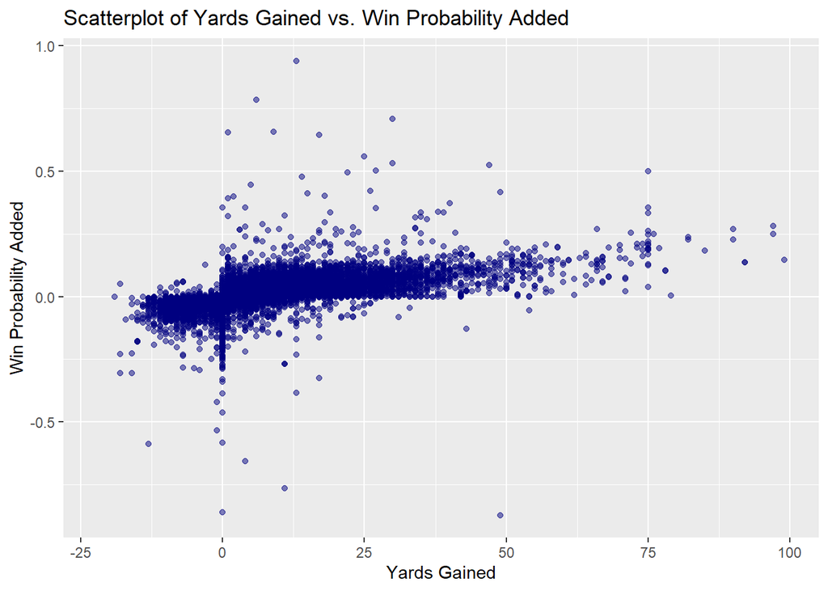

```r
#Generating scatterplot comparing yards gained to win probability added on the play
ggplot(data=play_data,aes(x=yards_gained,y=wpa))+geom_point(alpha=0.5,color="navy")+
  labs(title="Scatterplot of Yards Gained vs. Win Probability Added",x="Yards Gained",y="Win Probability Added")
```

Note the positive trend, with most yard-losing plays having a negative impact on win probability and win probability being increasingly positive, on average, as yardage increases. However, there is a lot of variability in win probability added given the yards gained, reflecting differences in the game situation across plays.

A key artefact of the data: the large number of no-gain plays with major negative win probability impacts is due to the fact that all interceptions are assigned a yardage of 0.

I suspect the majority of majorly impactful plays occurred in the fourth quarter, so let’s generate the same plot with the points segmented by quarter.

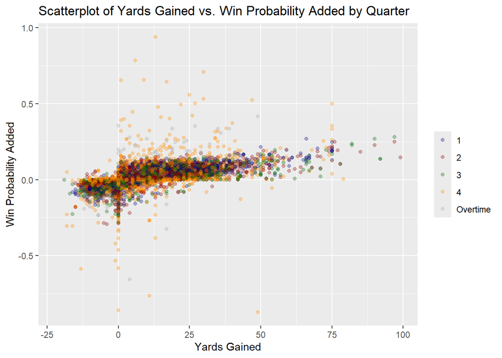

```r
#Generating scatterplot comparing yards gained to win probability added on the play
#with colors indicating the quarter the play occurred in
ggplot(data=play_data |> mutate(qtr=factor(qtr,levels=1:5,labels=c(1:4,"Overtime"))),aes(x=yards_gained,y=wpa,color=qtr))+geom_point(alpha=0.3)+
  scale_color_manual(values=c("navy","darkred","darkgreen","darkorange","darkgrey"))+
  labs(title="Scatterplot of Yards Gained vs. Win Probability Added by Quarter",x="Yards Gained",y="Win Probability Added",color=NULL)
```

It seems my hypothesis is correct, as most plays with a win probability impact above 0.5 in absolute value are in the fourth quarter (orange).

Let’s next explore the balance between run and pass plays for each team.

[figure not shown]

```r
#Plotting run-pass breakdown using faceting to produce a plot for each team
ggplot(data=play_data,aes(x=play_type,fill=play_type))+geom_bar(alpha=0.8)+facet_wrap(vars(posteam),ncol=4,axes="all",axis.labels="all")+
  scale_fill_manual(values=c("navy","darkred"))+theme_minimal()+
  #Testing some custom theming
  theme(
    plot.title.position = "plot",
    plot.title = element_text(face = "bold"),
    plot.background = element_rect(fill = "#F0F0F0"),
    #Add team name images for each plot based on team abbreviations
    strip.text = element_nfl_wordmark(size = 1),
  )+labs(title="Run-Pass Breakdown for Each Team",y="Number of Plays",fill=NULL)
```

It seems the Titans had the most balanced offense in the 2018-2019 season, while the Seahawks were the only team to run more than pass.

For the final plot, let’s visualize each team’s win probability across a single game. In particular, let’s plot the Eagles win probability across the game in their Week 1 match-up with the Falcons.

```r
#Filtering to a single game and generating tooltip info
play_data_1game<-play_data2 |>
  #Filtering to one game ID
  filter(game_id == 2018090600) |>
  #Removing end of quarter plays with no win probability
  drop_na(wp) |>
  #Creating play number variable
  mutate(dummy=1) |>
  mutate(play_num=cumsum(dummy)) |>
  #Constructing tooltip text
  mutate(tooltip=paste0("Quarter: ", qtr,
                              "<br>Game Clock: ", time,
                              "<br>Play: ", desc,
                              "<br>", home_team, " Win Probability: ", round(home_wp,3),
                        "<br>",away_team," Win Probability: ", round(away_wp,3)))

#Creating static version of the plot with line color matching home team's primary color
g<-ggplot(data=play_data_1game,aes(x=play_num,y=home_wp,color=home_team))+geom_line(linewidth=1.5)+scale_color_nfl(type = "primary") +
  coord_cartesian(ylim=c(0,1))+
  #Adding tooltip text into aesthetic for plotly
  geom_point(aes(text = tooltip), alpha = 0, size = 0.01, show.legend = FALSE)+
  labs(title="Win Probability for the Eagles in their Week 1 Game Against the Falcons",x="Play Number",y="Win Probability")
#Converting to dynamic plotly with tooltips
ggplotly(g,tooltip="text")
```

[interactive chart not shown]

It seems this was a back-and-forth game until the Eagles took the lead for the final time in the fourth quarter.